# Boulder BrainTrust<sup>TM</sup> graphics and Data Wrangling

cfelletter

Last updated: 2019-07-16

We have developed an R cookbook to make the process of creating publication-ready graphics in our in-house style using R’s ggplot2 library a more reproducible process, as well as making it easier for people new to R to create graphics. This was inspired by the [BBC’s cookbook](https://bbc.github.io/rcookbook/).

In addition to creating graphics, this cookbook also includes two sections on data wrangling. One is specific to working with RiverWare output in the form of rdf files, and the other is more generic. The idea here is to document wrangling problems we’ve solved, to make it easier to solve the next time.

**Let’s get the admin out of the way first…**

## Load all the libraries you need

A few of the steps in this cookbook - and to create charts in R in general - require certain packages to be installed and loaded. If these packages are not installed, you will need to install them first. Except for CRSSIO, all packages are available on CRAN. CRSSIO can be installed with `devtools::install_github("BoulderCodeHub/CRSSIO")`.

```r
library(RWDataPlyr)
library(tidyverse)
library(RWDataPlyr)
library(scales)
library(devtools)
library(CRSSIO)
library(tidyverse)
```

# Data Wrangling

## rdf Wrangling with RWDataPlyr

### Overview

RWDataPlyr is a tool to read and manipulate data generated from [RiverWare<sup>TM</sup>](http://www.riverware.org) simulations in rdf, csv, and nc formats and work with those data in a dplyr pipeline. It provides functions to gather, aggregate, and summarize data from multiple RiverWare simulations, i.e., scenarios.

### Installation

RWDataPlyr can be installed from CRAN:

```r
install.packages("RWDataPlyr")
```

Or the development version can be installed from GitHub:

```r
# install.packages("devtools")
devtools::install_github("BoulderCodeHub/RWDataPlyr")
```

### How does RWDataPlyr work?

RWDataPlyr provides at least three workflows for reading and using RiverWare data:

1. Reading and manipulating a single scenario
   - Fast
   - Best for inspecting a single slot
   - If comparing scenarios, must manually repeat for each scenario
   - Relies on `read_rdf()` and `read_rw_csv()`
2. Summarizing multiple slots of data from a single scenario
   - Repeatable; allows user to process many slots at once
   - Best for producing “polished” analyses of a single scenario
   - Relies on `rdf_aggregate()` and user specified `rwd_agg` object
3. Aggregating and summarizing many scenarios
   - Repeatable; allows user to process many slots for many scenarios at once
   - Repeats summary of a single scenario on multiple scenarios and combines results together
   - Relies on `rw_scen_aggregate()` and user specified `rwd_agg` object

Check out the workflow vignette for more details:

```r
vignette("rwdataplyr-workflow", package = "RWDataPlyr")
```

The code below shows how data from `rw_scen_aggregate()` and user specified `rwd_agg` can be used within standard chart-production workflow. In this is example monthly data from the `RWDataPlyr` package has already been aggregated to an annual EOCY value. The example creates a boxplot of the EOCY values to compare two scenarios.

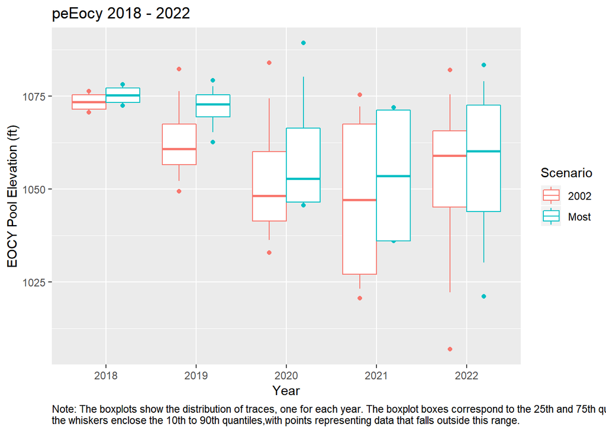

```r
#Load required scripts to create the custom plot types
source('code/Stat_emp_ExcCrv.r')

#Data for chart from RWDataPlyr package
scen_res <- RWDataPlyr::scen_data

#Specify variables for chart and data minipulation
variable <- "peEocy"
y_lab <- "EOCY Pool Elevation (ft)"
title <- "EOCY Pool Elevation (ft)"
startyr <- 2018
endyr <- 2022
caption <- "Note: The boxplots show the distribution of traces, one for each year. The boxplot boxes correspond to the 25th and 75th quantiles,\nthe whiskers enclose the 10th to 90th quantiles,with points representing data that falls outside this range."

#minipulate data
df <- scen_res %>%
  dplyr::filter(Variable == variable) %>%
  dplyr::filter(startyr <= Year && Year <= endyr) %>% #filter year
  dplyr::group_by(Scenario, Year)

#plot data
p <- df %>%
  ggplot(aes(x = factor(Year), y = Value, color = Scenario)) +
  CRSSIO::stat_boxplot_custom(qs = c(0.1, 0.25, 0.5, 0.75, 0.9)) +
  labs(title = paste(variable,startyr,"-",endyr),
       y = y_lab, x = "Year", caption = caption) +
  theme(plot.caption = element_text(hjust = 0)) #left justify

#print graph
print(p)
```

## Converting rdfs to Excel

CADSWES provides the [RdfToExcel](https://cadswes2.colorado.edu/downloads/riverware/releases/index.html) tool to convert rdf files to Excel files. This tool can be used interactively, or within RiverSMART to automate the conversion process. However, sometimes, it can be useful to batch convert a lot of rdf files outside of RiverSMART. The conversion can be scripted in R.

**Make sure that the file paths do not include any spaces**

```r
# path to the executable
rdf2excel <- "C:/Program Files/CADSWES/RdfToExcel/RdfToExcelExecutable.exe"

ifile <- system.file(
  "extdata/Scenario/ISM1988_2014,2007Dems,IG,Most/KeySlots.rdf",
  package = "RWDataPlyr"
)

ofile <- file.path(tempdir(), "KeySlots.xlsx")

lfile <- file.path(tempdir(), "rdf2excel.log")

# construct the command arguements as a vector
my_args <- c("-i", ifile, "-o", ofile, "-l", lfile)

# call the executable with the arguments
system2(rdf2excel, args = my_args)
```

The “-l” flag does not have to be used; it will create a log file in the input directory. Similarly, if the output file is not specified, it will create the file in the input directory with the same name as the rdf file, but with a xlsx extension.

# Plotting

## Predefined Plotting with RW-RDF-Process-Plot Scripts

### RW-RDF-Process-Plot Scripts Example

The following example is intended to demonstrate how the master scripts could be used to generate plots which compare two different runs of the MTOM model. This is done by modifying `code/MTOM_Process&Plot_Generics.R` in the RW-RDF-Process-Plot directory.

#### RDF File Loactions

The first block of code specifies the location of the scenario rdf files from the completed RiverWare runs.

```r
# +++++++++++++++++++++++++++++++++++++++++++++++++++++++++++++++++++++++++++++
## 1. Set Up ##
# +++++++++++++++++++++++++++++++++++++++++++++++++++++++++++++++++++++++++++++
rm(list=ls()) #clear the enviornment

library(RWDataPlyr)

## Directory Set Up
# where scenarios are folder are kept
scen_dir <- file.path(getwd(),"scenarios")
#containing the sub folders for each ensemble

results_dir <- file.path(getwd(),"results")

# +++++++++++++++++++++++++++++++++++++++++++++++++++++++++++++++++++++++++++++
## 2. User Input ##
# +++++++++++++++++++++++++++++++++++++++++++++++++++++++++++++++++++++++++++++

############# RDF File Loactions - Change For New Study ########################

#list scenarios folders in scen_dir
list.dirs(scen_dir) #list dirs in set folder folder for us in next input

#scens you want to compare, list as "your plot name" = "folder name"
scens <- list(
  "PreviousRun" = "PreviousRun",
  "CurrentRun" = "CurrentRun"
)

#list rdf files in dir
list.files(file.path(scen_dir,scens[1])) #list files in scen folder for next input
```

If the rdf files for the scenarios are in the [RW-RDF-Process-Plot directory]/scenarios /CurrentRun and /PreviousRun folders you are set. If they are elsewhere the `scen_dir` variable must be changed. If you would like a custom folder location and plot name you could use the following for `scens`

```r
scens <- list(
  "Jan Offc" =  "CRSS.V2.8.0.2019.9704.Aug2018,DNF,2007Dems,IG_v2.7.0.9700,Most",
  "FG Dev" = "CRSS.V2.8.0.2019.9703.Aug2018,DNF,2007Dems,IG_v2.7.0.9700,Most"
  )
```

#### Plot Specifications

The next code block is where you specify the rdfs, variables and plot types as well as additional plot features.

```r
############# Specify Plots ########################

# Process Variables ##
rdffiles <- c("Res.rdf","Res.rdf","Res.rdf") #rdf file with slot you want
variables <- c("Powell.Inflow","Powell.Pool Elevation","Mead.Inflow") #RW Object.Slot
timesteps <- c("monthly","annual","annual") #"annual" or "monthly" or "daily"
# #WARNING: Daily Plots are still under development and all results should be cross checked.
# #Avoid using figuretypes 2 is Bxplt of Traces & 3 is Exceedance until further developement is complete.
# #https://github.com/usbr/RW-RDF-Process-Plot/issues/17
floworpes <- c("flow","pe","flow") #"flow" or "pe"
cyorwys <- c("cy","cy","wy") #"cy" or "wy". wy not tested for all plot configurations
mainScenGroup <<- names(scens)[2] #name of the subfolder this analysis will be stored
## Plot Variables ##
combineplots <<- F #F for individual files saved, true to combineplots multiple file
#Note: creating a series of seperate files
figuretypes <- c(1,2,3) #1 is Trace Mean, 2 is Bxplt of Traces, 3 is Exceedance
exc_months <- c(NA,NA,9) #1 - Jan, 12 - Dec rep(NA,times = length(variables))
#Note: must specify exc_month for Exceedance, since we want wy this is 9/sept
startyrs <<- rep(2019,times = length(variables)) #c(2019,2019,2019,2019,2019) #filter out all years > this year
endyrs <<- rep(2022,times = length(variables)) #c(2019,2026,2026,2026) #filter out all years > this year
#Note: start year same as end year for Daily
customcaptions <-  c(NA,NA,"Inflow Exceedance") #NA or this will over write the default caption on boxplots rep(NA,times = length(variables))
custom_y_labs <- c(NA,NA,"Inflow Exceedance") #NA gives defaults, enter if want soemthing different rep(NA,times = length(variables))
# Note: use of custom caption and labels
figname <<- "ExampleFigs"
model <<- "MTOM" #"CRSS" or "MTOM"
first_ensemble <<- c(4,4) #filter out Most,Min,Max. For 38 trace offical = 4,
minmaxchk <- T #only works for monthly currently (12/6/18)

############# Standard Plot Variables - Don't Change ########################

#output image parameters
width <<- 9 #inches
height <<- 6

imgtype <<- "png" #supports pdf, png, jpeg. pdf looks the best
#only works when individual plots are selected

# +++++++++++++++++++++++++++++++++++++++++++++++++++++++++++++++++++++++++++++
#                               END USER INPUT
# +++++++++++++++++++++++++++++++++++++++++++++++++++++++++++++++++++++++++++++
```

Plots are listed in order with a `,` seperating each in the variable declareation. Any number of plots can be generated but each variable must be specified for all plots. Hit `Ctrl + Alt + R` to run the code and create the figures in your `results_dir` In this example our plots will be:

1. A monthly mean of the traces of Powell.Inflow

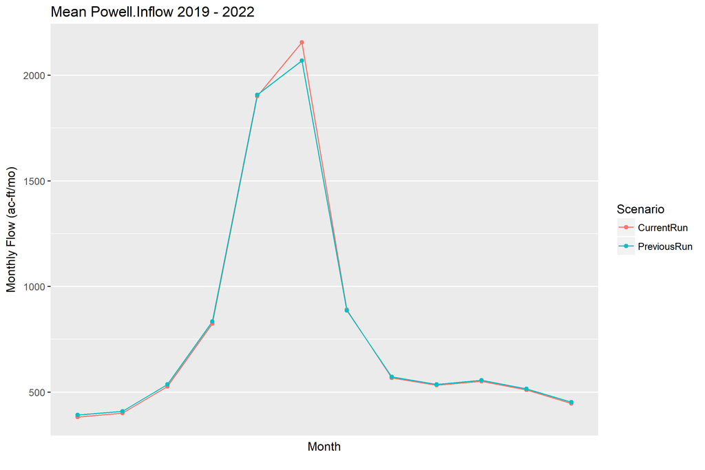

1. A annual boxplot of the traces of Powell.Pool Elevation

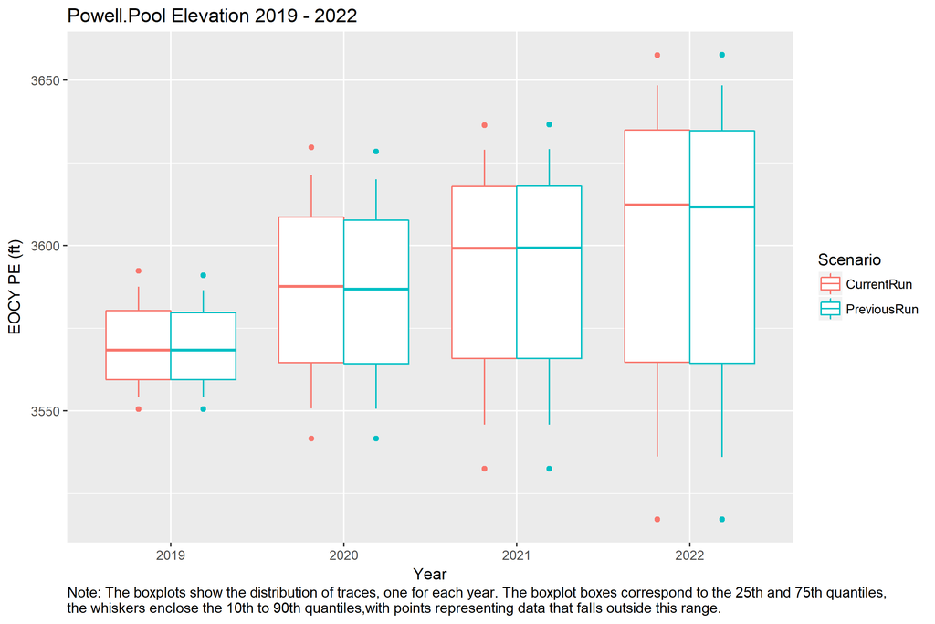

1. A annual exceedance of the traces of Mead.Inflow

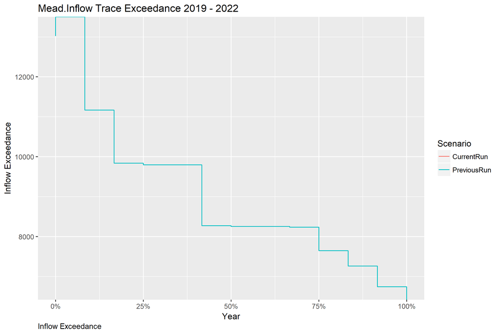

All plots are from 2019-2022 and will be generated as png files.

Further infromation follows about setup up and the uses of individual functions in the RW-RDF-Process-Plot family. **Users lacking experience with R will want to only modify the master scripts** `code/MTOM_Process&Plot_Generics.R` and `code/CRSS_Process&Plot_Generics.R` which call the appropriate functions.

### Generate rdf Files from RiverWare

1. Use RiverWare MRM to generate rdf Files from MTOM or CRSS
2. Option A: Move files for the current run to ./scenarios/currentrun folder. Move old rdf files into ../scenarios/previousrun folder
3. Option B: Later modify code to point scen_dir at the location of your scenarios

### Setup RW-RDF-Process-Plot

#### If its your first time using the MTOM R process script and/or R in general

Ensure the following are installed: * [R (3.4.4)](https://cran.r-project.org/) * [R tools](https://cran.rstudio.com/bin/windows/Rtools/) * R tools must be added to the Path environment variable. This is an option while installing R tools, so as long as it is performed during the install, no additional steps are necessary. * [RStudio desktop](https://www.rstudio.com/products/rstudio/download/)

**First time Running R (or after installing a new version)**

The first time you use R, or when upgrading to a new releases (e.g., 3.4.x to 3.5.x), it will take some time (~20 minutes) to install all of the necessary R packages. After the first time, it will be much quicker.

1. Double-click MTOM.Rproj to launch the R-Studio project. You should get the following message:

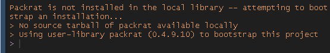

2. Install all necessary packages, using either method a, or b.
   1. Type `packrat::restore()` in the R-console and hit enter
   2. Use the R-studio GUI options *this does not seem to be available in all versions of RStudio)
   - Navigate to the Packages tab (in the lower right pane of RStudio)
   - If the down carrot (see picture) is available, click it, then click “Check Library Status”. If it’s not available, use method **a)** to install the packages.

[figure not shown]

   Packrat RStudio options

   - You should receive a message that many of the packages need updating. Click “Restore”
3. If you receive any errors, **close RStudio, reopen it**, and then type `packrat::restore()` in the R console and press enter to continue the installation.
4. **Close RStudio, and Reopen it.**

#### If you’ve previously cloned RW-RDF-Process-Plot

1. Open the repository in git extensions
2. Start up the Git Bash control line
3. Enter `$ git remote set-url origin https://github.com/usbr/RW-RDF-Process-Plot.git`

#### If you have a previous packrat library you want to move into this repository

Moving previous packrat library (from MTOM directory or other) 1. Clone the package to your local area where you have write access 1. Move your packrat file from your MTOM folder to this location a. Don’t overwrite any existing files in this repo 1. Run `packrat::init()` to init packrat. 1. In the lower right window verify Packages lists a Packrat Library with all files having descriptions

### Master Model Scripts

Master scripts are designed to make plotting results simple. These scripts take user input then call the process and plot functions. **Users lacking experience with R will want to only modify the master scripts.**

1. open __code/[MODEL XXXX]_Process&Plot_Generics.R__
2. update scen_dir and results_dir in **1. Set Up** if scenarios aren’t listed location or you want a custom results location
3. update the variables in **2.UserInput** section
4. Optional: save the changes as a custom name. Don’t save and push these in the **code** folder unless its a standard analysis for the team. Instead save them to the **custom_code_notrack** folder.
5. Ctrl + Alt + R to run the code and create the figures in your results_dir

### Supporting Functions

Master scripts utilize the following functions were are explained below:

#### Process Function

This function processes annual, monthly or daily output from CRSS & MTOM for reservoir Inflow, Outflow (“flow”) or Pool Elevation (“pe”).

#### Generic Plot Functions

These functions are called by the master scripts after Generic_Scen_Process() returns scen_res. The functions can process designed for reservoir Inflow, Outflow (“flow”) or Pool Elevation (“pe”). The functions allow users to pick one of 3 figure types (1) Trace Mean, (2) Boxpolt of all Traces, (3) is Exceedance.

##### Generic Annual Plot

Annual period of Calendar Year (“cy”) or Water Year (“wy”) must be specified. Plotting varies based on if the slot is a “flow”, monthly values are summed over the annual period, or if a “pe”, value for the end of the annual period (CY = Dec, WY = Sept) is used.

Data is plotted “asis.” If plotting (3) Exceedance you must specify a exc_month of 1-12 (1 - Jan, 12 - Dec).

##### Generic Daily Plot

Data processing is not available via RWDataPlyr functions so output from daily slots is handled differently than the above. It is not recommended that you use this script to look at more than one year of data so the script defaults to taking only the year listed as startyr. When plotting (1) Trace Mean is all the daily means as individual data points but NOTE: the months appear to start in Feb since first CRSS timestep is Jan 31. For (2) Boxpolt of all Traces the boxplots show the distribution of daily flow grouped by month. (3) Exceedance is the CDF for all daily flows.

WARNING: Daily Plots are still under development and all results should be cross checked.Avoid using figuretypes 2 is Bxplt of Traces & 3 is Exceedance until further developement is complete. https://github.com/usbr/RW-RDF-Process-Plot/issues/17

#### Generic Input Check

This function checks the input provided in the master scripts

## Custom plots by writting your own R Script

Sample data to use, which includes EOCY Mead elevation and annual Powell release.

```r
scen_path <- system.file("extdata/Scenario", package = "RWDataPlyr")

rwa <- rwd_agg(data.frame(
  file = "KeySlots.rdf",
  slot = c("Powell.Outflow", "Mead.Pool Elevation"),
  period = c("cy", "eocy"),
  summary = c("sum", NA),
  eval = NA,
  t_s = NA,
  variable = c("powell_out", "mead_pe"),
  stringsAsFactors = FALSE
))

scens <- c(
  "most" = "ISM1988_2014,2007Dems,IG,Most",
  "other_ic" = "ISM1988_2014,2007Dems,IG,2002"
)

rdftbl <- rw_scen_aggregate(scens, agg = rwa, scen_dir = scen_path)
```

### Plot means of all traces

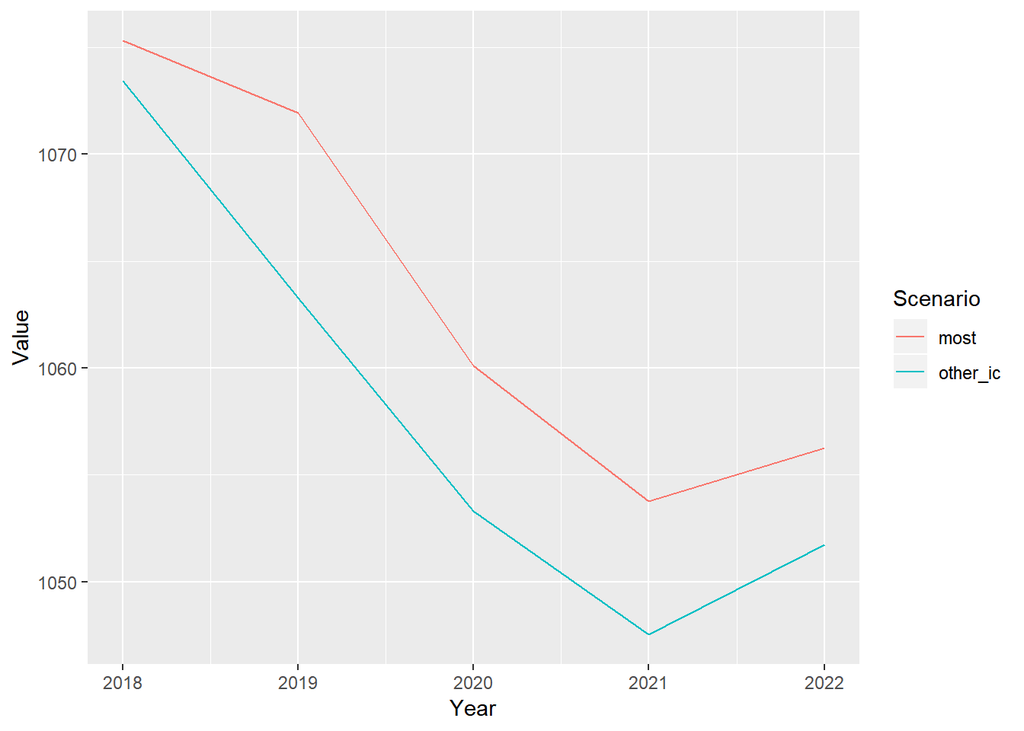

```r
rdftbl %>%
  filter(Variable == "mead_pe") %>%
  group_by(Scenario, Year) %>%
  summarise(Value = mean(Value)) %>%
  ggplot(aes(Year, Value, color = Scenario)) %+%
  geom_line()
```

### How to plot a histogram of trace values

*that unfortunately this project was not funded.*

### How to plot exceedances of all traces

*I’m afraid your on your own.*

### How to get trace min/max

*It’s a cold dark stackoverflow out there…*

## Further Customize your plots with these features

### Transparent Backgrounds

- set the plot regions to transparent
- and set the output background to transparent

```r
## gg is some ggplot
gg <- gg +
  theme(rect = element_rect(fill = "transparent"))

# or for more control (not all rectangles)
gg <- gg +
  theme(
    panel.background = element_rect(fill = "transparent"),
    plot.background = element_rect(fill = "transparent"),
    legend.background = element_rect(fill = "transparent"),
    legend.box.background = element_rect(fill = "transparent")
  )

ggsave(gg, "sample.png", bg = "transparent")
```

### Horizontal lines for only part of the x-axis